# Template for lab 1 report for BIOS 20152

Sarah Greta

## Part 1: Computation using variables

- Heart pumping with a constant rate, where $V_{tot}$ is the total volume of blood pumped by the heart over time, $V_s$ is the stroke volume, $R$ is the heart rate and $t$ is time:
  $$V_{tot} = V_sRt$$
- Bacterial population that doubles every hour, where $P$ is the current population, $P_0$ is the initial population, and $t$ is the elapsed time:
  $$P = P_0 2^t$$
- The rate of an enzyme-catalyzed reaction, where $v$ is the rate of the reaction, $v_{max}$ is the maximum reaction rate, $K_M$ is the Michaelis constant, and $A$ is concentration of the substrate:
  $$v = \frac{v_{max} A}{K_M+A}$$
1. Use the heart-pumping model to calculate the volume of blood pumped by a heart beating at 80 beats per minute with stroke volume of 70 ml over 80 minutes (the length of one class) by creating variables for the stroke volume, heart rate, and time (come up with your own descriptive names). Perform the calculation and assign the result to a variable, then print out the answer.

```r
heartrate <- 80
strokeV <-70
timepassed <-80
totalvolumeofblood <- heartrate*strokeV*timepassed
print(totalvolumeofblood)
```

```
## [1] 448000
```

Total volume of blood pumped by the heart: 448000 mL

2. Use the model to alculate the bacterial population after 3 days if the initial population is a million by creating variables for the growth time and initial population. Perform the calculation and assign the result to a variable, then print out the answer.

```r
initialpopulation <- 1e6
hourspassed <- 3*24
currentpopulation <- initialpopulation*2^hourspassed
print(currentpopulation)
```

```
## [1] 4.722366e+27
```

Current population: 4.722366e27 bacteria

3. Use the model for Michealis-Menten kinetics to calculate the rate of the reaction given the substrate concentration of 1 mM, the maximum rate of 10 per second, and the Michaelis constant of 30 mM by creating variables for the substrate concentration, maximum reaction rate, the Michaelis constant. Perform the calculation and assign the result to a variable, then print out the answer.

```r
substrateconcentration <- 1
maxrate <- 10
Mikesconstant <-30
rateofreaction <- {maxrate*substrateconcentration}/{Mikesconstant+substrateconcentration}
print(rateofreaction)
```

```
## [1] 0.3225806
```

Rate of reaction: 0.3225806 reactions per second

## Part 2: Plotting in R

1. Plot the dependence of total blood pumped by the heart on the elapsed time, based on the heart pumping model from Part 1. To do this, set time to be a vector from 0 to 80 minutes with step 1 minute and calculate a vector of values of volume using your script from Task 1.1 and keeping the same values of stroke volume and heart rate. Plot the volume vs time using the type line with black line color and label your axes. Then change the heart rate to 120 beats per minute and overlay that plot on top of the previous one using the **lines()** command with red line color. Based on the plots, describe what kind of function is this model, and what is the graphical difference between the two graphs.

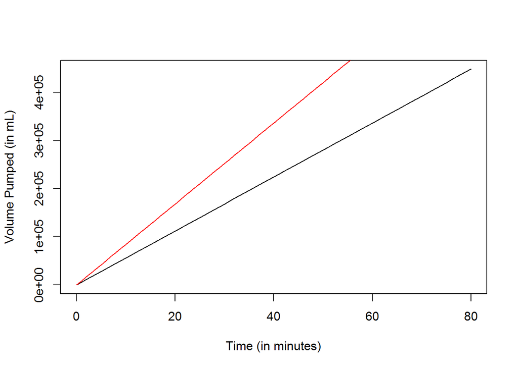

```r
time <- seq(0,80,1)
heartrate <- 80
strokeV <- 70
totalvolumeofblood <- heartrate*strokeV*time
plot(time,totalvolumeofblood, type="l", xlab="Time (in minutes)", ylab="Volume Pumped (in mL)")
heartrate <- 120
totalvolumeofblood <- heartrate*strokeV*time
lines(time,totalvolumeofblood, col="red")
```

Both functions are linear functions because they have a constant slope over the domain. The graphical difference between the two is a difference in slope with the red line having a larger slope.

2. Plot the dependence of bacterial population on the time, based on the bacterial population model from Part 1. To do this, set time to be a vector from 0 to 3 days with step of 1 hour, and calculate a vector of values of population using your script from Task 1.2 and keeping the same initial population. Plot the population vs time using the type line with black line color and label your axes. Then change the initial population to 2 million and overlay that plot on top of the previous one using the **lines()** command with red line color. Based on the plots, describe what kind of function is this model, and what is the graphical difference between the two graphs.

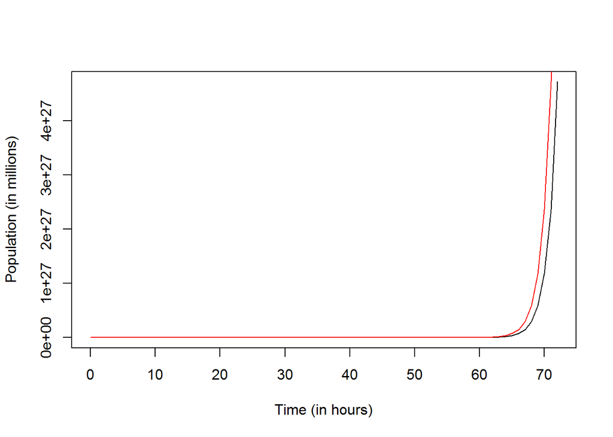

```r
time <- seq(0,72,1)
initialpopulation <- 1e6
currentpopulation <- initialpopulation*2^time
plot(time,currentpopulation, type="l", xlab="Time (in hours)", ylab="Population (in millions)")
initialpopulation <- 2e6
currentpopulation <- initialpopulation*2^time
lines(time,currentpopulation, col="red")
```

The two functions are expontential functions, which have the form f(x)=ae^kx. The graphical difference between the two graphs is a difference in the a value. The red graph has a larger value for a, so the graph increases to infinity sooner than the black graph.

3. Plot the dependence of the reaction rate on the substrate concentration, based on the Michaelis-Menten model from Part 1. To do this, set substrate concentration to be a vector from 0 to 100 mM with step of 1 mM, and calculate a vector of values of reaction rate using your script from Task 1.3 and keeping the same values for all the other variables. Plot the reaction rate vs concentration using the type line with black line color and label your axes. Based on the plot, at what value of concentration is the reaction rate equal to half of the maximum rate $v_{max}$? Change the Michaelis constant $K_M$ to be 60 mM and overlay that plot on top of the previous one using the **lines()** command with red line color, and report at what concentration is the reaction rate one half of $v_{max}$. How is this value influenced by $K_M$?

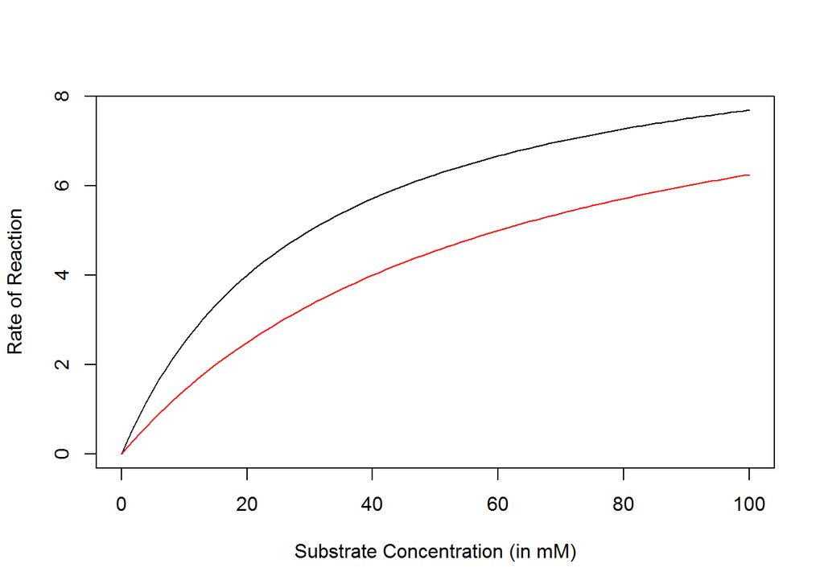

```r
substrateconcentration <- seq(0,100,1)
maxrate <- 10
Mikesconstant <-30
rateofreaction <- {maxrate*substrateconcentration}/{Mikesconstant+substrateconcentration}
plot(substrateconcentration,rateofreaction, type="l", xlab="Substrate Concentration (in mM)", ylab="Rate of Reaction")
Mikesconstant <- 60
rateofreaction <- {maxrate*substrateconcentration}/{Mikesconstant+substrateconcentration}
lines(substrateconcentration,rateofreaction, col="red")
```

Half of the maximum rate is 5 reactions per second, which corresponds to an approximate concentration 30 mM for the black graph. For the red graph, a reaction rate of 5 reactions per second correponds to an approximate concentration of 60 mM. For each graph, the value of the concentration at half the maximum reaction rate corresponds to the value of the Michaelis constant, so doubling the Michaelis constant will double the concentration required to reach half the maximum reaction rate.

## Part 3: Reading in data and fitting functions by eye

1. Make a plot of Kong$Mutations vs Kong$PatAge using circles (the default type). Decide whether it resembles a linear or exponential function, guess the parameters and overlay a plot of the appropriate function over the data plot using **lines()**. Try different parameter values until you find ones that fit the data reasonably well.

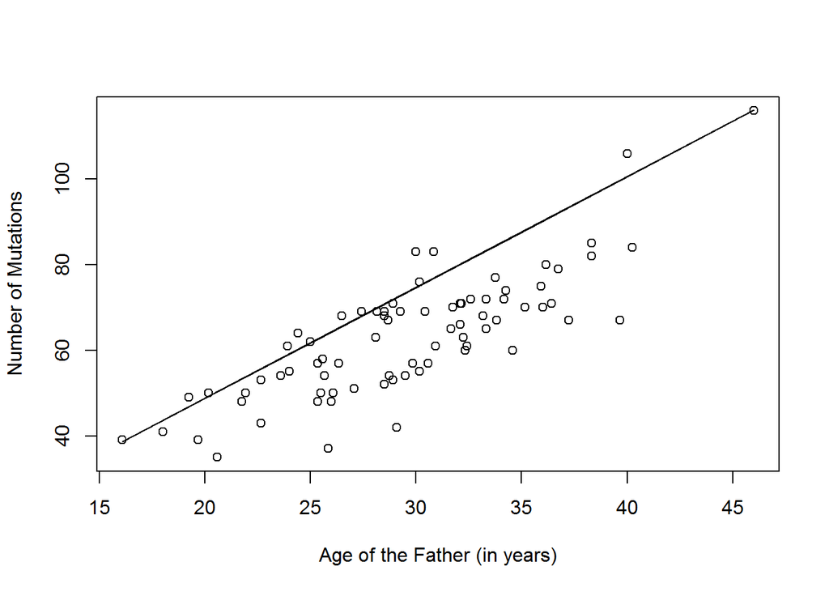

```r
mutationdata <- read.table("kong_mutation_data.txt", header=TRUE)
plot(mutationdata$PatAge,mutationdata$Mutations, xlab="Age of the Father (in years)", ylab="Number of Mutations")
x <- mutationdata$PatAge
y <- 2.59*x-3
lines(x,y)
```

The plot resembles a linear function with a slope of 2.59 and a y-intercept of -3.

2. Make a plot of Kong$Mutations vs Kong$MatAge using circles (the default type). Decide whether it resembles a linear or exponential function, guess the parameters and overlay a plot of the appropriate function over the data plot using **lines()**. Try different parameter values until you find ones that fit the data reasonably well.

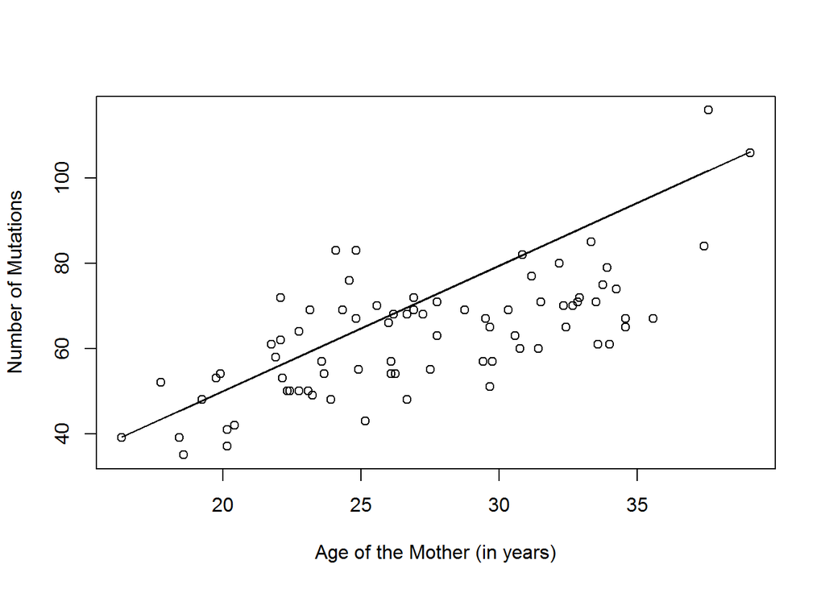

```r
plot(mutationdata$MatAge,mutationdata$Mutations, xlab="Age of the Mother (in years)", ylab="Number of Mutations")
x <- mutationdata$MatAge
y <- 2.95*x-9
lines(x,y)
```

The plot resembles a linear function with a slope of 2.95 and a y-intercept of -9.

3. Make a plot of Insulin$Conc vs Insulin$Time using circles (the default type). Decide whether it resembles a linear or exponential function, guess the parameters and overlay a plot of the appropriate function over the data plot using **lines()**. Try different parameter values until you find ones that fit the data reasonably well.

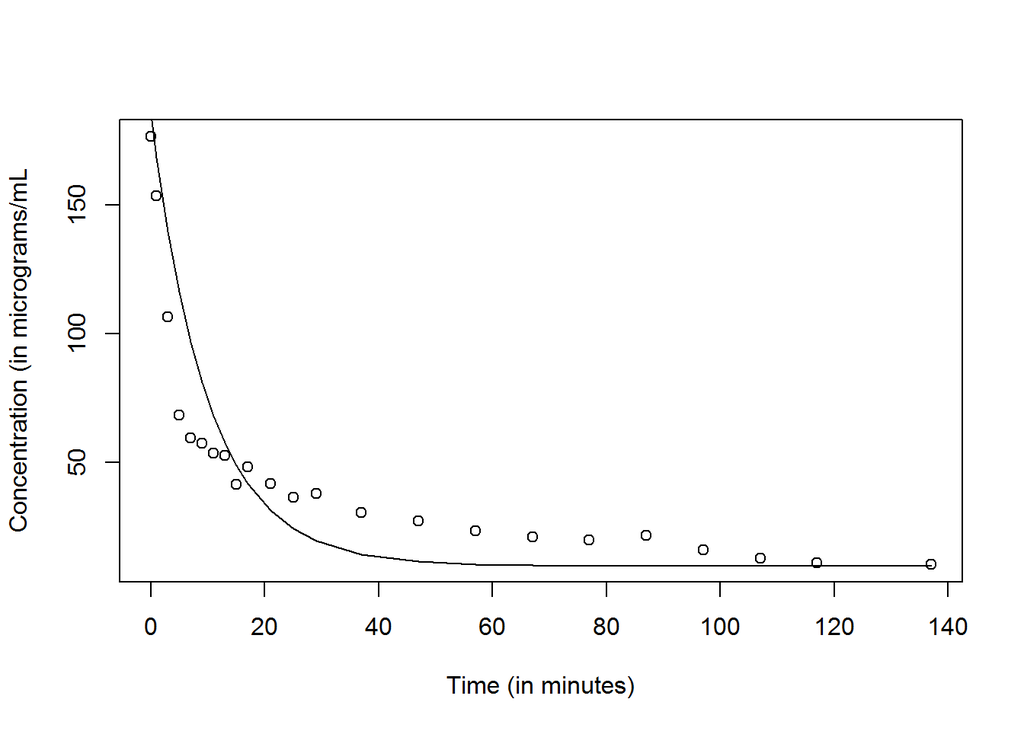

```r
insulindata <- read.table("Insulin_data.txt", header=TRUE)
plot(insulindata$Time,insulindata$Conc, xlab="Time (in minutes)", ylab="Concentration (in micrograms/mL")
x <- insulindata$Time
y <- 175*exp(-0.1*x)+10
lines(x,y)
```

4. Make a plot of KaiC$Amount vs KaiC$Time using circles (the default type). Decide whether it resembles a linear or exponential function, guess the parameters and overlay a plot of the appropriate function over the data plot using **lines()**. Try different parameter values until you find ones that fit the data reasonably well.

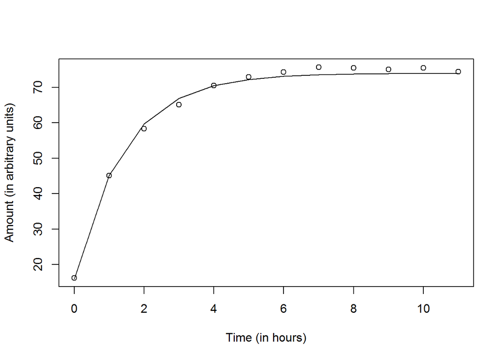

```r
proteindata <- read.table("KaiC_data.txt", header=TRUE)
plot(proteindata$Time,proteindata$Amount, xlab="Time (in hours)", ylab="Amount (in arbitrary units)")
x <- proteindata$Time
y <- -58*exp(-0.7*x)+74
lines(x,y)
```